# HTKS EF Devsci analysis

# Methods

```r
DFsmall %>%
  select(location, Sex = sex, Age = age_yr2, BMI = bmi, 'Years of Schooling' = edu_exposure) %>%
  gtsummary::tbl_summary(
    by = location,
    statistic = c(Age, BMI, 'Years of Schooling') ~ "{mean} ({sd}) {min} - {max}",
    digits = c(Age, BMI, 'Years of Schooling') ~ 2,
    missing_text = "(Missing)"
  )
```

| **Characteristic** | **Brazil**, N = 30<sup>1</sup> | **Ghana**, N = 31<sup>1</sup> | **Vanuatu**, N = 20<sup>1</sup> | **Malaysia**, N = 26<sup>1</sup> |
| --- | --- | --- | --- | --- |
| Sex |  |  |  |  |
| f | 17 (57%) | 15 (48%) | 11 (55%) | 12 (46%) |
| m | 13 (43%) | 16 (52%) | 9 (45%) | 14 (54%) |
| Age | 10.21 (0.94) 8.60 - 12.10 | 10.68 (1.18) 8.40 - 12.30 | 10.99 (1.16) 9.30 - 12.90 | 10.95 (1.14) 8.90 - 12.60 |
| BMI | 19.22 (3.83) 13.87 - 26.73 | 15.90 (2.48) 13.73 - 27.37 | 13.72 (3.72) 7.95 - 19.24 | 17.74 (4.31) 13.44 - 34.80 |
| Years of Schooling | 6.23 (1.04) 3.00 - 8.00 | 8.03 (1.38) 6.00 - 10.00 | 3.55 (1.99) 1.00 - 7.00 | 6.27 (2.63) 0.00 - 9.00 |

<sup>*1*</sup> n (%); Mean (SD) Range

Compulsory years of schooling were added manually for each fieldsite in this table.

# Results

## *Summary Stats*

### Table 3. Scores on the HTKS, Knox Cube, and Beads Tasks by site.

| **Characteristic** | **Overall**, N = 107<sup>1</sup> | **Brazil**, N = 30 | **Ghana**, N = 31 | **Vanuatu**, N = 20 | **Malaysia**, N = 26 |
| --- | --- | --- | --- | --- | --- |
| HTKS All |  |  |  |  |  |
| Mean (SD) | 49.87 (7.90) | 51.43 (4.74) | 48.13 (8.55) | 45.45 (10.25) | 53.54 (5.87) |
| Median | 52.00 | 52.50 | 48.00 | 49.00 | 55.50 |
| HTKS I & II | 35.78 (4.10) | 36.80 (2.35) | 34.77 (4.36) | 33.00 (5.64) | 37.92 (2.10) |
| Knox Cube | 6.81 (2.81) | 5.63 (3.07) | 6.16 (2.71) | 7.25 (2.29) | 8.62 (2.00) |
| Beads | 3.22 (2.36) | 3.90 (2.60) | 2.42 (1.77) | 2.10 (2.22) | 4.27 (2.20) |

<sup>*1*</sup> c("Mean (SD)", "Median"); Mean (SD)

### Figures 2a and 2b: Violin plots showing HTKS scores by study site. The dashed line represents the maximum possible score.

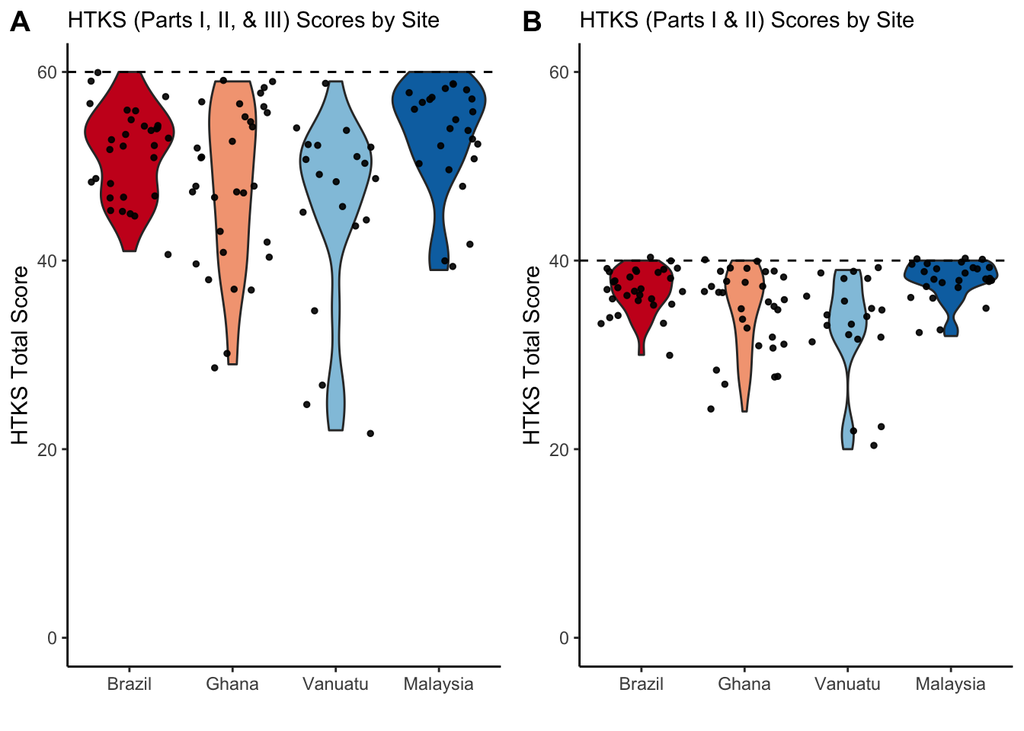

### Table 4. Results of five one-way ANOVAs for site-level differences in variables.

```r
anova_bmi <- aov(bmi ~ location, data = DFsmall)
summary(anova_bmi)
```

```
##              Df Sum Sq Mean Sq F value Pr(>F)
## location      3  411.8  137.28   10.58  4e-06 ***
## Residuals   103 1336.4   12.98
## ---
## Signif. codes:  0 '***' 0.001 '**' 0.01 '*' 0.05 '.' 0.1 ' ' 1
```

```r
anova_age <- aov(age_yr ~ location, data = DFsmall)
summary(anova_age)
```

```
##              Df Sum Sq Mean Sq F value Pr(>F)
## location      3  10.45   3.482   2.873 0.0399 *
## Residuals   103 124.85   1.212
## ---
## Signif. codes:  0 '***' 0.001 '**' 0.01 '*' 0.05 '.' 0.1 ' ' 1
```

```r
anova_edu <- aov(edu_exposure ~ location, data = DFsmall)
summary(anova_edu)
```

```
##              Df Sum Sq Mean Sq F value   Pr(>F)
## location      3  244.3   81.42   24.93 3.31e-12 ***
## Residuals   103  336.4    3.27
## ---
## Signif. codes:  0 '***' 0.001 '**' 0.01 '*' 0.05 '.' 0.1 ' ' 1
```

```r
anova_knox <- aov(knox_total_z ~ location, data = DFsmall)
summary(anova_knox)
```

```
##              Df Sum Sq Mean Sq F value   Pr(>F)
## location      3  18.15   6.050   7.094 0.000222 ***
## Residuals   103  87.85   0.853
## ---
## Signif. codes:  0 '***' 0.001 '**' 0.01 '*' 0.05 '.' 0.1 ' ' 1
```

```r
anova_beads <- aov(beads_total_z ~ location, data = DFsmall)
summary(anova_beads)
```

```
##              Df Sum Sq Mean Sq F value   Pr(>F)
## location      3  15.64   5.214   5.944 0.000885 ***
## Residuals   103  90.36   0.877
## ---
## Signif. codes:  0 '***' 0.001 '**' 0.01 '*' 0.05 '.' 0.1 ' ' 1
```

```r
#Combining outputs together in a table
anova_sum <- rbind(
anova_summary(anova_bmi),
anova_summary(anova_age),
anova_summary(anova_edu),
anova_summary(anova_knox),
anova_summary(anova_beads)) %>% select(-c('p<.05','ges')) %>% as.data.frame()

# Replace effect column with correct effect names
anova_sum$IV <- as.character(c('BMI (m/kg^2)','Age (years)','Years of Schooling (years)', 'Knox Cube Score (z-scored)','Beads Score (z-scored)')) # Create column naming independent variable
anova_sum <- anova_sum %>%
  select(IV,DFn, DFd, F, p) %>%
  kable(.) %>%
  kable_styling(bootstrap_options = c("striped", "hover"))

# Print table
anova_sum
```

| IV | DFn | DFd | F | p |
| --- | --- | --- | --- | --- |
| BMI (m/kg^2) | 3 | 103 | 10.580 | 0.000004 |
| Age (years) | 3 | 103 | 2.873 | 0.040000 |
| Years of Schooling (years) | 3 | 103 | 24.931 | 0.000000 |
| Knox Cube Score (z-scored) | 3 | 103 | 7.094 | 0.000222 |
| Beads Score (z-scored) | 3 | 103 | 5.944 | 0.000885 |

### Table 5. Summary of Tukey’s HSD posthoc tests for demographic and cognitive variables and location.

Because all of our demographic/cognitive variables are significantly different by site (see Table 4 anovas), we’re running posthoc tests (Tukey’s HSD) to review specific site-site differences.

Posthoc results were combined into a single table by hand to maximize efficient use of space. Here, we will show full results of each posthoc test, including confidence intervals, for each ANOVA.

Tukey’s HSD - BMI:

```r
TukeyHSD(anova_bmi)
```

```
##   Tukey multiple comparisons of means
##     95% family-wise confidence level
##
## Fit: aov(formula = bmi ~ location, data = DFsmall)
##
## $location
##                       diff       lwr        upr     p adj
## Ghana-Brazil     -3.316506 -5.725663 -0.9073483 0.0027730
## Vanuatu-Brazil   -5.491929 -8.207437 -2.7764210 0.0000043
## Malaysia-Brazil  -1.477939 -3.998449  1.0425715 0.4227136
## Vanuatu-Ghana    -2.175423 -4.873355  0.5225085 0.1581488
## Malaysia-Ghana    1.838567 -0.662997  4.3401312 0.2263689
## Malaysia-Vanuatu  4.013991  1.216176  6.8118054 0.0016613
```

Tukey’s HSD - Age:

```r
TukeyHSD(anova_age)
```

```
##   Tukey multiple comparisons of means
##     95% family-wise confidence level
##
## Fit: aov(formula = age_yr ~ location, data = DFsmall)
##
## $location
##                         diff         lwr       upr     p adj
## Ghana-Brazil      0.47064516 -0.26570371 1.2069940 0.3452347
## Vanuatu-Brazil    0.78500000 -0.04498369 1.6149837 0.0707700
## Malaysia-Brazil   0.73615385 -0.03422952 1.5065372 0.0665685
## Vanuatu-Ghana     0.31435484 -0.51025673 1.1389664 0.7522834
## Malaysia-Ghana    0.26550868 -0.49908391 1.0301013 0.8012264
## Malaysia-Vanuatu -0.04884615 -0.90398656 0.8062943 0.9988094
```

Tukey’s HSD - Years of Schooling:

```r
TukeyHSD(anova_edu)
```

```
##   Tukey multiple comparisons of means
##     95% family-wise confidence level
##
## Fit: aov(formula = edu_exposure ~ location, data = DFsmall)
##
## $location
##                         diff       lwr        upr     p adj
## Ghana-Brazil      1.79892473  0.590226  3.0076235 0.0010206
## Vanuatu-Brazil   -2.68333333 -4.045731 -1.3209353 0.0000076
## Malaysia-Brazil   0.03589744 -1.228668  1.3004630 0.9998529
## Vanuatu-Ghana    -4.48225806 -5.835838 -3.1286782 0.0000000
## Malaysia-Ghana   -1.76302730 -3.018087 -0.5079671 0.0021682
## Malaysia-Vanuatu  2.71923077  1.315539  4.1229229 0.0000109
```

Tukey’s HSD - Knox Score:

```r
TukeyHSD(anova_knox)
```

```
##   Tukey multiple comparisons of means
##     95% family-wise confidence level
##
## Fit: aov(formula = knox_total_z ~ location, data = DFsmall)
##
## $location
##                       diff        lwr       upr     p adj
## Ghana-Brazil     0.1879665 -0.4297067 0.8056396 0.8566963
## Vanuatu-Brazil   0.5755755 -0.1206416 1.2717926 0.1417919
## Malaysia-Brazil  1.0616881  0.4154657 1.7079105 0.0002334
## Vanuatu-Ghana    0.3876091 -0.3041017 1.0793198 0.4632973
## Malaysia-Ghana   0.8737216  0.2323567 1.5150865 0.0031391
## Malaysia-Vanuatu 0.4861126 -0.2312068 1.2034319 0.2937988
```

Tukey’s HSD - Beads Scores:

```r
TukeyHSD(anova_beads)
```

```
##   Tukey multiple comparisons of means
##     95% family-wise confidence level
##
## Fit: aov(formula = beads_total_z ~ location, data = DFsmall)
##
## $location
##                        diff        lwr           upr     p adj
## Ghana-Brazil     -0.6262056 -1.2526352  0.0002240015 0.0501178
## Vanuatu-Brazil   -0.7612695 -1.4673565 -0.0551825680 0.0293284
## Malaysia-Brazil   0.1561579 -0.4992257  0.8115413938 0.9247402
## Vanuatu-Ghana    -0.1350639 -0.8365807  0.5664528267 0.9582432
## Malaysia-Ghana    0.7823634  0.1319062  1.4328206376 0.0116198
## Malaysia-Vanuatu  0.9174274  0.1899390  1.6449157699 0.0073140
```

### Figures 3a-d. Site-level distributions of years of schooling and task scores (HTKS, Knox Cube, and Beads).

[figure not shown]

## *Is there a relationship between HTKS performance and EFs (as measured by the Knox Cube and Beads Tasks) across all sites?*

### Figure 4. Pearson Correlations for HTKS, Knox Cube Task, and Beads Task scores.

Here we create the correlation matrix:

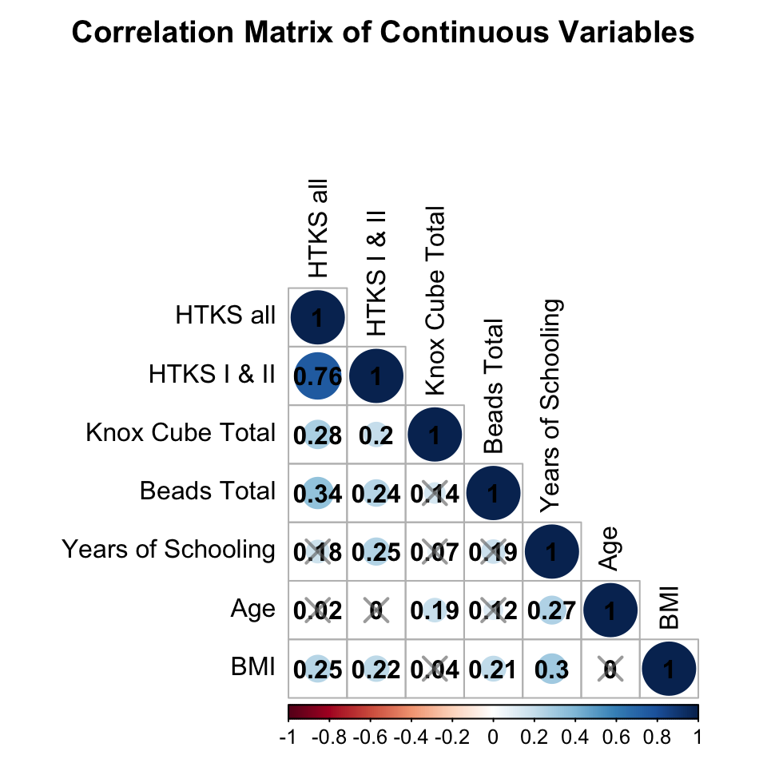

```r
#Select only continuous variables for correlation analysis
dfcorrs = DFsmall %>% select(HTKS_all,HTKS_i_ii, knox_total, beads_total, edu_exposure, age_yr, bmi) %>% drop_na()

colnames(dfcorrs) <- c('HTKS all','HTKS I & II', 'Knox Cube Total', 'Beads Total', 'Years of Schooling','Age', 'BMI') #Names of columns to be used in plots


dfcorrs.rcorr = rcorr(as.matrix(dfcorrs)) #Create correlation matrix

dfcorrs.coeff = dfcorrs.rcorr$r #Save corr coefficients
dfcorrs.p = dfcorrs.rcorr$P #Save corr p-values


grey <- adjustcolor("#696969", alpha.f = 0.6) #Create grey with adjusted opacity

#Make correlation plot
corrplot(dfcorrs.coeff,
         method = "circle",
         type = "lower",
         title = "Correlation Matrix of Continuous Variables", mar=c(0,0,2,0),
         p.mat = dfcorrs.p, addCoef.col = "black", #Add significance values
         insig = "pch", pch = 4, pch.col = grey, pch.cex = 2, #Add x's to insignificant correlations
         tl.col = "black", tl.pos = "ld") #Position/color for text labels
```

### Figure 5a & b. Scatterplots of Knox Cube and Beads scores against HTKS scores, respectively.

```r
#Create plot 5a
plot3 = ggplot(DFsmall, aes(knox_total, HTKS_all, color=location)) +
  stat_smooth(method="glm", family = binomial, formula=y~x,
              alpha=0.2, size=2, aes(fill=location)) +
  geom_point(position=position_jitter(height=0.02, width=0.02),size=3, alpha=0.3) +
  coord_cartesian(ylim = c(19.95, 60.05), , xlim = c(-.05, 15.05))+
  theme_minimal()+
  ylab("HTKS Total (out of 60)") +
  xlab("Knox Cube Total (out of 15)") +
  theme(axis.title = element_text(angle = 90, vjust = -0.075),
        axis.title.x = element_text(angle = 0, size = 20),
        axis.title.y = element_text(size = 20),
        axis.text = element_text(size = 16),
        legend.text = element_text(size = 16),
        legend.title = element_text(size = 16),
        plot.title = element_text(size = 20, face = "bold"))+
  theme(strip.text.x = element_text(size = 18, colour = "black", angle = 0),
        strip.text.y = element_text(size = 18, colour = "black", angle = 270)) +
  scale_color_brewer(palette="RdBu")
```

```r
#Create plot 5b
plot4 = ggplot(DFsmall, aes(beads_total, HTKS_all, color=location)) +
  stat_smooth(method="glm", family = binomial, formula=y~x,
              alpha=0.2, size=2, aes(fill=location)) +
  geom_point(position=position_jitter(height=0.02, width=0.02),size=3, alpha=0.3) +
  coord_cartesian(ylim = c(19.95, 60.05), , xlim = c(-.05, 10.05))+
  theme_minimal()+
  ylab("HTKS Total (out of 60)") +
  xlab("Beads Total (out of 10)") +
  theme(axis.title = element_text(angle = 90, vjust = -0.075),
        axis.title.x = element_text(angle = 0, size = 20),
        axis.title.y = element_text(size = 20),
        axis.text = element_text(size = 16),
        legend.text = element_text(size = 16),
        legend.title = element_text(size = 16),
        plot.title = element_text(size = 20, face = "bold"))+
  theme(strip.text.x = element_text(size = 18, colour = "black", angle = 0),
        strip.text.y = element_text(size = 18, colour = "black", angle = 270)) +
  scale_color_brewer(palette="RdBu")
```

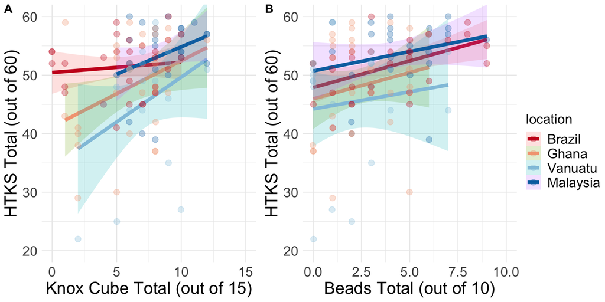

```r
# Combine plots 5a & b
plot_3_4 <- ggarrange(plot3, plot4, common.legend = TRUE, legend = "right", labels = c("A", "B"))
plot_3_4
```

### Table 6. Results of the full model of independent variables and HTKS scores

*Is there a relationship between HTKS performance and EFs (as measured by the Knox and Beads tasks) in our overall sample?*

We’ll first run the full model to answer this question. Here, we’re running the model itself first.

```r
#Run full model
mboth = lm(HTKS_all ~ age_yr_c + sex + bmi_c + yrs_school_c + location + beads_total_z + knox_total_z,  data=DFsmall, na.action = na.fail)
```

#### Check assumptions

Now, we’ll check the assumption - resid plots, VIFs, and formal test for heteroskedasticity with the studentized Breusch-Pagan test.

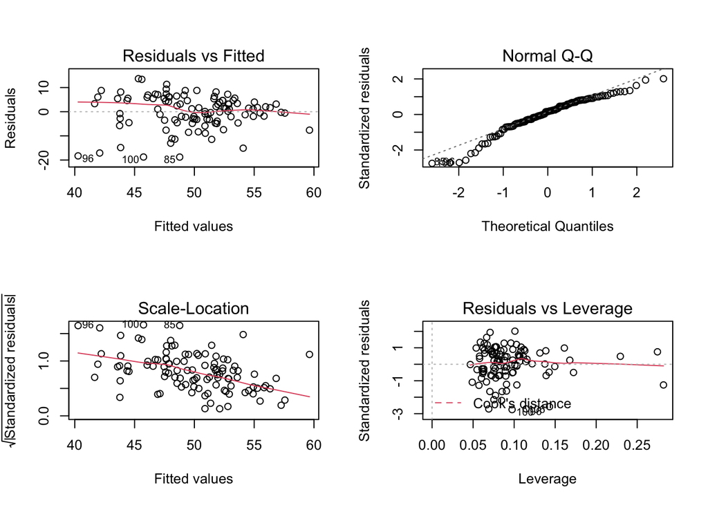

```r
#Residual and Q-Q plot
par(mfrow=c(2,2)) # init 4 charts in 1 panel
plot(mboth)
```

```r
#Check variance inflation factors for parameters
car::vif(mboth)
```

```
##                   GVIF Df GVIF^(1/(2*Df))
## age_yr_c      1.369324  1        1.170181
## sex           1.012287  1        1.006125
## bmi_c         1.426553  1        1.194384
## yrs_school_c  2.452194  1        1.565948
## location      3.947155  3        1.257131
## beads_total_z 1.252232  1        1.119032
## knox_total_z  1.278909  1        1.130889
```

```r
#BP test
bptest(mboth)
```

```
##
##  studentized Breusch-Pagan test
##
## data:  mboth
## BP = 20.783, df = 9, p-value = 0.01365
```

Looks like VIFs all look good, ranging from 1-1.6, so no concerns there.

The residual plot does look to be heteroskedastic, which is confirmed by a BP test. To account for this, we will calculate robust standard errors and confidence intervals.

```r
#Model parameters, where SE, CI and p-values are based on robust estimation
tab_model(mboth, vcov.fun = "HC", show.se = TRUE)
```

|  | HTKS all |  |  |  |
| --- | --- | --- | --- | --- |
| Predictors | Estimates | std. Error | CI | p |
| (Intercept) | 51.29 | 1.30 | 48.70 – 53.88 | **<0.001** |
| age_yr_c | -0.27 | 0.79 | -1.83 – 1.30 | 0.733 |
| sex [m] | 0.06 | 1.49 | -2.90 – 3.03 | 0.966 |
| bmi_c | 0.15 | 0.23 | -0.30 – 0.60 | 0.520 |
| yrs_school_c | 0.20 | 0.45 | -0.70 – 1.09 | 0.664 |
| location [Ghana] | -2.42 | 2.26 | -6.91 – 2.08 | 0.288 |
| location [Vanuatu] | -4.34 | 2.75 | -9.79 – 1.12 | 0.118 |
| location [Malaysia] | 0.24 | 1.99 | -3.71 – 4.19 | 0.904 |
| beads_total_z | 1.58 | 0.74 | 0.11 – 3.05 | **0.036** |
| knox_total_z | 1.90 | 0.89 | 0.15 – 3.66 | **0.034** |
| Observations | 107 |  |  |  |
| R<sup>2</sup> / R<sup>2</sup> adjusted | 0.245 / 0.175 |  |  |  |

```r
#Calculate AICc score
MuMIn::AICc(mboth)
```

```
## [1] 739.592
```

### Table 7. Best fit model of independent variables and HTKS scores

This section is running a model selection process from all possible parameter combinations. This did not include interaction terms - interactions of interest are examined later.

```r
# run model selection by AICc
model_sel <- dredge(mboth) #dredge from full model

# Show top 10 models
model_sel[1:10]
```

```
## Global model call: lm(formula = HTKS_all ~ age_yr_c + sex + bmi_c + yrs_school_c +
##     location + beads_total_z + knox_total_z, data = DFsmall,
##     na.action = na.fail)
## ---
## Model selection table
##    (Int) age_yr_c bds_ttl_z  bmi_c knx_ttl_z lct sex yrs_sch_c df   logLik
## 27 51.81              1.634            2.002   +                7 -357.907
## 15 49.87              2.116 0.3537     1.838                    5 -360.400
## 31 51.41              1.603 0.1632     1.940   +                8 -357.533
## 91 51.80              1.552            1.924   +        0.2053  8 -357.769
## 16 49.87 -0.42580     2.164 0.3504     1.923                    6 -360.162
## 79 49.87              2.055 0.3204     1.819            0.2100  6 -360.168
## 28 51.76 -0.09116     1.651            2.011   +                8 -357.896
## 59 51.78              1.634            2.003   +   +            8 -357.906
## 11 49.87              2.419            1.853                    4 -362.476
## 25 52.36                               2.198   +                6 -360.374
##     AICc delta weight
## 27 730.9  0.00  0.224
## 15 731.4  0.45  0.179
## 31 732.5  1.59  0.101
## 91 733.0  2.06  0.080
## 16 733.2  2.22  0.074
## 79 733.2  2.23  0.074
## 28 733.3  2.32  0.070
## 59 733.3  2.34  0.070
## 11 733.3  2.40  0.068
## 25 733.6  2.64  0.060
## Models ranked by AICc(x)
```

```r
# Pull best fitting model
best_model <- get.models(model_sel, subset = 1)[[1]]
```

#### Check assumptions

Like above, we’ll check resid plots, VIFs, and test for heteroskedasticity with the studentized Breusch-Pagan test.

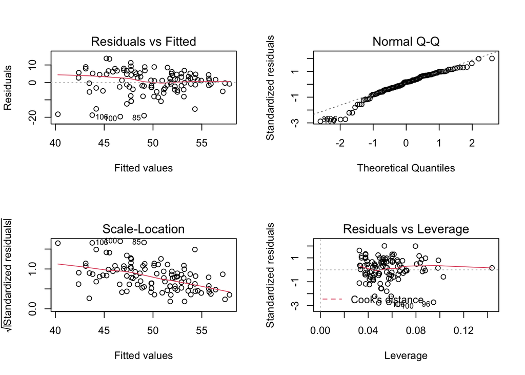

```r
#Residual and Q-Q plot
par(mfrow=c(2,2)) # init 4 charts in 1 panel
plot(best_model)
```

```r
#Check variance inflation factors for parameters
car::vif(best_model)
```

```
##                   GVIF Df GVIF^(1/(2*Df))
## beads_total_z 1.189768  1        1.090765
## knox_total_z  1.223740  1        1.106228
## location      1.405757  3        1.058405
```

```r
#BP test
bptest(best_model)
```

```
##
##  studentized Breusch-Pagan test
##
## data:  best_model
## BP = 17.519, df = 5, p-value = 0.003614
```

Looks like heteroskedasticity is also a problem here, so we will calculate robust standard errors.

```r
#Model summary table
tab_model(best_model, vcov.fun = "HC", show.se = TRUE)
```

|  | HTKS all |  |  |  |
| --- | --- | --- | --- | --- |
| Predictors | Estimates | std. Error | CI | p |
| (Intercept) | 51.81 | 0.94 | 49.95 – 53.67 | **<0.001** |
| beads_total_z | 1.63 | 0.65 | 0.33 – 2.93 | **0.014** |
| knox_total_z | 2.00 | 0.84 | 0.34 – 3.66 | **0.019** |
| location [Ghana] | -2.66 | 1.82 | -6.28 – 0.96 | 0.148 |
| location [Vanuatu] | -5.89 | 2.51 | -10.86 – -0.92 | **0.021** |
| location [Malaysia] | -0.28 | 1.69 | -3.62 – 3.07 | 0.871 |
| Observations | 107 |  |  |  |
| R<sup>2</sup> / R<sup>2</sup> adjusted | 0.238 / 0.200 |  |  |  |

```r
#Calculate aicc
MuMIn::AICc(mboth)
```

```
## [1] 739.592
```

## *Does formal education impact the relationship between HTKS and EF tasks?*

### Figure 6. Comparison of full model and years of schooling moderation effect models.

Running a moderation analysis to assess years of schooling as a moderator of location effects, Knox Cube, or Beads effect

```r
#Interactions - yrs school and location
mboth_int_loc = lm(HTKS_all ~ age_yr_c + sex + bmi_c + yrs_school_c + location + yrs_school_c*location + beads_total_z + knox_total_z,  data=DFsmall)
car::vif(mboth_int_loc)
```

```
##                            GVIF Df GVIF^(1/(2*Df))
## age_yr_c               1.727243  1        1.314246
## sex                    1.014660  1        1.007303
## bmi_c                  1.562112  1        1.249845
## yrs_school_c          22.948538  1        4.790463
## location              11.374756  3        1.499652
## beads_total_z          1.345026  1        1.159753
## knox_total_z           1.372350  1        1.171473
## yrs_school_c:location 94.702200  3        2.134978
```

```r
tab_model(mboth_int_loc)
```

|  | HTKS all |  |  |
| --- | --- | --- | --- |
| Predictors | Estimates | CI | p |
| (Intercept) | 50.94 | 47.66 – 54.23 | **<0.001** |
| age_yr_c | -0.62 | -2.25 – 1.00 | 0.448 |
| sex [m] | 0.08 | -2.72 – 2.88 | 0.954 |
| bmi_c | 0.18 | -0.25 – 0.61 | 0.417 |
| yrs_school_c | 0.56 | -2.29 – 3.42 | 0.696 |
| location [Ghana] | -4.06 | -9.60 – 1.49 | 0.150 |
| location [Vanuatu] | -4.44 | -11.28 – 2.39 | 0.200 |
| location [Malaysia] | 0.72 | -3.76 – 5.20 | 0.750 |
| beads_total_z | 1.71 | 0.09 – 3.33 | **0.039** |
| knox_total_z | 1.71 | 0.07 – 3.34 | **0.041** |
| yrs_school_c * location [Ghana] | 0.77 | -2.55 – 4.08 | 0.647 |
| yrs_school_c * location [Vanuatu] | -0.65 | -3.94 – 2.65 | 0.698 |
| yrs_school_c * location [Malaysia] | -0.52 | -3.55 – 2.51 | 0.733 |
| Observations | 107 |  |  |
| R<sup>2</sup> / R<sup>2</sup> adjusted | 0.255 / 0.160 |  |  |

```r
#Interactions - yrs school and knox
mboth_int_knox = lm(HTKS_all ~ age_yr_c + sex + bmi_c + yrs_school_c + location + beads_total_z + knox_total_z + yrs_school_c*knox_total_z,  data=DFsmall)
car::vif(mboth_int_knox)
```

```
##                               GVIF Df GVIF^(1/(2*Df))
## age_yr_c                  1.390313  1        1.179115
## sex                       1.018987  1        1.009449
## bmi_c                     1.426872  1        1.194518
## yrs_school_c              2.741071  1        1.655618
## location                  4.181138  3        1.269256
## beads_total_z             1.253752  1        1.119711
## knox_total_z              1.280231  1        1.131473
## yrs_school_c:knox_total_z 1.152172  1        1.073393
```

```r
tab_model(mboth_int_knox)
```

|  | HTKS all |  |  |
| --- | --- | --- | --- |
| Predictors | Estimates | CI | p |
| (Intercept) | 51.27 | 48.05 – 54.48 | **<0.001** |
| age_yr_c | -0.30 | -1.75 – 1.15 | 0.685 |
| sex [m] | 0.10 | -2.69 – 2.89 | 0.944 |
| bmi_c | 0.15 | -0.26 – 0.56 | 0.476 |
| yrs_school_c | 0.25 | -0.74 – 1.23 | 0.622 |
| location [Ghana] | -2.46 | -6.98 – 2.05 | 0.282 |
| location [Vanuatu] | -4.16 | -9.90 – 1.58 | 0.154 |
| location [Malaysia] | 0.28 | -4.09 – 4.66 | 0.899 |
| beads_total_z | 1.57 | 0.02 – 3.13 | **0.048** |
| knox_total_z | 1.91 | 0.34 – 3.48 | **0.018** |
| yrs_school_c * knox_total_z | -0.14 | -1.01 – 0.74 | 0.760 |
| Observations | 107 |  |  |
| R<sup>2</sup> / R<sup>2</sup> adjusted | 0.245 / 0.167 |  |  |

```r
#Interactions - yrs school and beads
mboth_int_beads = lm(HTKS_all ~ age_yr_c + sex + bmi_c + yrs_school_c + location + beads_total_z + knox_total_z + yrs_school_c*beads_total_z,  data=DFsmall)
car::vif(mboth_int_beads)
```

```
##                                GVIF Df GVIF^(1/(2*Df))
## age_yr_c                   1.405760  1        1.185647
## sex                        1.018148  1        1.009033
## bmi_c                      1.486161  1        1.219082
## yrs_school_c               2.466803  1        1.570606
## location                   4.665485  3        1.292655
## beads_total_z              1.259016  1        1.122059
## knox_total_z               1.280821  1        1.131734
## yrs_school_c:beads_total_z 1.400270  1        1.183330
```

```r
tab_model(mboth_int_beads)
```

|  | HTKS all |  |  |
| --- | --- | --- | --- |
| Predictors | Estimates | CI | p |
| (Intercept) | 51.20 | 47.98 – 54.43 | **<0.001** |
| age_yr_c | -0.21 | -1.66 – 1.25 | 0.780 |
| sex [m] | 0.12 | -2.67 – 2.91 | 0.931 |
| bmi_c | 0.17 | -0.25 – 0.59 | 0.422 |
| yrs_school_c | 0.18 | -0.76 – 1.11 | 0.708 |
| location [Ghana] | -2.19 | -6.77 – 2.38 | 0.344 |
| location [Vanuatu] | -4.80 | -10.67 – 1.07 | 0.108 |
| location [Malaysia] | 0.21 | -4.15 – 4.58 | 0.923 |
| beads_total_z | 1.55 | -0.01 – 3.11 | 0.051 |
| knox_total_z | 1.92 | 0.35 – 3.49 | **0.017** |
| yrs_school_c * beads_total_z | 0.20 | -0.54 – 0.94 | 0.589 |
| Observations | 107 |  |  |
| R<sup>2</sup> / R<sup>2</sup> adjusted | 0.247 / 0.169 |  |  |

```r
#Check AICc values for all 3 interaction models
MuMIn::AICc(mboth_int_loc, mboth_int_knox, mboth_int_beads)
```

```
##                 df     AICc
## mboth_int_loc   14 745.9154
## mboth_int_knox  12 742.0274
## mboth_int_beads 12 741.8055
```

Below display the interaction models against the full model to check for differences in effects. Effects are unmoderated by years of schooling (see how little effects change across all models).

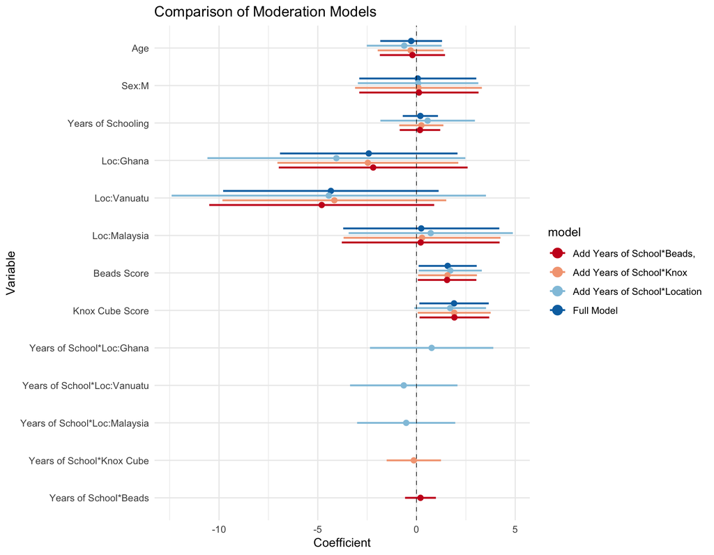

```r
# To visually display the coefficients from main and interaction models at once

coef.names <- c("Age"="age_yr_c", "Sex:M"="sexm","BMI"="bmi","Years of Schooling"="yrs_school_c",
                 "Loc:Ghana"="locationGhana","Loc:Vanuatu"="locationVanuatu",
                "Loc:Malaysia"="locationMalaysia", "Beads Score"="beads_total_z",
                "Knox Cube Score"="knox_total_z","Years of School*Loc:Ghana"="yrs_school_c:locationGhana",
              "Years of School*Loc:Vanuatu"= "yrs_school_c:locationVanuatu",
              "Years of School*Loc:Malaysia"= "yrs_school_c:locationMalaysia",
               "Years of School*Knox Cube"= "yrs_school_c:knox_total_z",
              "Years of School*Beads"= "yrs_school_c:beads_total_z")

mod_regression_plot <- plot_summs(mboth, mboth_int_loc, mboth_int_knox, mboth_int_beads,
                                  exp = FALSE,
                                  model.names = c('Full Model', 'Add Years of School*Location',
                                                  'Add Years of School*Knox',
                                                  'Add Years of School*Beads,'),
                                  coefs = coef.names,
                                  point.shape = FALSE,
                                  robust = TRUE)  +
  theme_minimal() +
  labs(x = "Coefficient", y = 'Variable', title = 'Comparison of Moderation Models') +
  scale_shape_manual(values=c(20,20,20,20), guide = FALSE) +
  scale_color_brewer(palette="RdBu")

mod_regression_plot
```

## *Effect of experimental variation in task environment and administration?*

### Table 8. Linear model results examining the number of practice trials and HTKS performance

|  | HTKS all |  |  |
| --- | --- | --- | --- |
| Predictors | Estimates | CI | p |
| (Intercept) | 49.12 | 40.79 – 57.44 | **<0.001** |
| HTKS_practice | 0.05 | -0.39 – 0.49 | 0.837 |
| Observations | 99 |  |  |
| R<sup>2</sup> / R<sup>2</sup> adjusted | 0.000 / -0.010 |  |  |

Looks like the practice trials aren’t an influence on HTKS scores from this model, so we won’t worry about them.

### Figures 7a & 7b. Background noise level and EF task scores across sites

Background noise was rated as 0,1,2 by coders. 0 = silent/lab-like setting 1 = intermittent noise or constant low level noise 2 = loud background noise (yelling, lots of talking, etc.)

To look at whether the EF task totals are different based on background noise levels, we’ll look at the data and run an ANOVA for the Knox task total score and the Beads Task total score.

```
##                 Df Sum Sq Mean Sq F value Pr(>F)
## back_noise_knox  2    9.9   4.941   0.662  0.519
## Residuals       71  530.2   7.467
## 33 observations deleted due to missingness
```

```
##                  Df Sum Sq Mean Sq F value Pr(>F)
## back_noise_beads  2   17.7   8.861   1.679  0.192
## Residuals        88  464.4   5.278
## 16 observations deleted due to missingness
```

Now we’ll plot these:

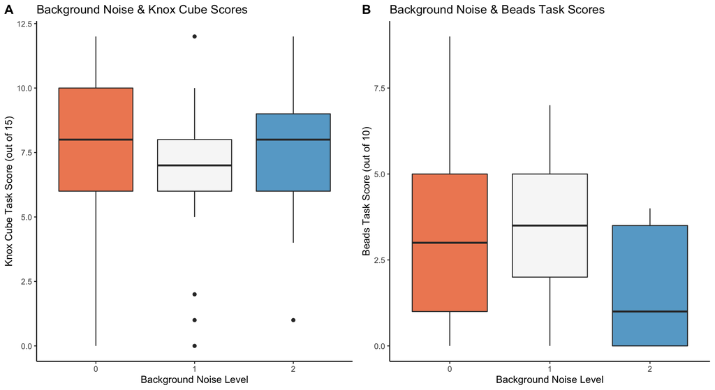

# Suppplemental Materials

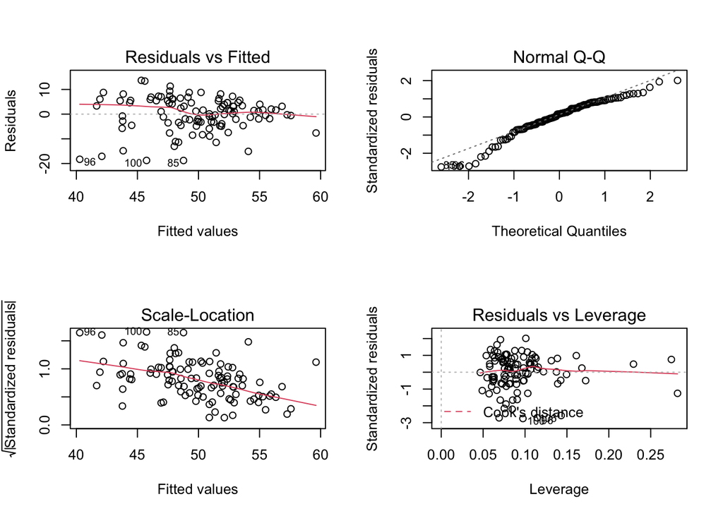

```r
#Residual and Q-Q plot
par(mfrow=c(2,2)) # init 4 charts in 1 panel
plot(mboth)
```

### Table Supp3. Results of Model 1, including age, sex, BMI, and location variables

Here and for each model below this we will output the main model table, GVIFs, and AICc

```r
# save model
mbase <- lm(HTKS_all ~ age_yr_c + sex + bmi_c + location,  data=DFsmall)

# output table w/ robust SE
tab_model(mbase, vcov.fun = "HC", show.se = TRUE)
```

|  | HTKS all |  |  |  |
| --- | --- | --- | --- | --- |
| Predictors | Estimates | std. Error | CI | p |
| (Intercept) | 51.03 | 1.37 | 48.31 – 53.75 | **<0.001** |
| age_yr_c | 0.25 | 0.68 | -1.11 – 1.60 | 0.719 |
| sex [m] | -0.06 | 1.50 | -3.03 – 2.91 | 0.970 |
| bmi_c | 0.23 | 0.21 | -0.18 – 0.65 | 0.273 |
| location [Ghana] | -2.65 | 1.97 | -6.56 – 1.26 | 0.182 |
| location [Vanuatu] | -4.91 | 2.46 | -9.79 – -0.03 | **0.049** |
| location [Malaysia] | 2.27 | 1.75 | -1.20 – 5.74 | 0.197 |
| Observations | 107 |  |  |  |
| R<sup>2</sup> / R<sup>2</sup> adjusted | 0.150 / 0.099 |  |  |  |

```r
# VIF/GVIFs
car::vif(mbase)
```

```
##              GVIF Df GVIF^(1/(2*Df))
## age_yr_c 1.099801  1        1.048714
## sex      1.009950  1        1.004963
## bmi_c    1.326698  1        1.151824
## location 1.449175  3        1.063784
```

```r
#Calculate aicc
MuMIn::AICc(mbase)
```

```
## [1] 744.8965
```

### Table Supp4. Results of Model 2, including age, sex, BMI, years of schooling, and location variables

```r
# save model
mbase_sch <- mbase_sch <- lm(HTKS_all ~ age_yr_c + sex + bmi_c + yrs_school_c + location,  data=DFsmall)

# output table w/ robust SE
tab_model(mbase_sch, vcov.fun = "HC", show.se = TRUE)
```

|  | HTKS all |  |  |  |
| --- | --- | --- | --- | --- |
| Predictors | Estimates | std. Error | CI | p |
| (Intercept) | 51.03 | 1.36 | 48.34 – 53.72 | **<0.001** |
| age_yr_c | -0.13 | 0.85 | -1.82 – 1.56 | 0.876 |
| sex [m] | -0.08 | 1.50 | -3.05 – 2.90 | 0.960 |
| bmi_c | 0.17 | 0.20 | -0.23 – 0.56 | 0.401 |
| yrs_school_c | 0.55 | 0.51 | -0.46 – 1.55 | 0.284 |
| location [Ghana] | -3.66 | 2.13 | -7.90 – 0.57 | 0.089 |
| location [Vanuatu] | -3.50 | 2.84 | -9.13 – 2.13 | 0.221 |
| location [Malaysia] | 2.44 | 1.77 | -1.08 – 5.96 | 0.172 |
| Observations | 107 |  |  |  |
| R<sup>2</sup> / R<sup>2</sup> adjusted | 0.161 / 0.102 |  |  |  |

```r
# VIF/GVIFs
car::vif(mbase_sch)
```

```
##                  GVIF Df GVIF^(1/(2*Df))
## age_yr_c     1.360634  1        1.166462
## sex          1.010072  1        1.005024
## bmi_c        1.423818  1        1.193238
## yrs_school_c 2.322411  1        1.523946
## location     2.807522  3        1.187738
```

```r
#Calculate aicc
MuMIn::AICc(mbase_sch)
```

```
## [1] 745.8541
```

### Table Supp5. Results of Model 3, including age, sex, BMI, location, Knox Cube score, and Beads score variables.

```r
# save model
mbothns  = lm(HTKS_all ~ age_yr_c + sex + bmi_c + location + beads_total_z + knox_total_z,  data=DFsmall)

# output table w/ robust SE
tab_model(mbothns, vcov.fun = "HC", show.se = TRUE)
```

|  | HTKS all |  |  |  |
| --- | --- | --- | --- | --- |
| Predictors | Estimates | std. Error | CI | p |
| (Intercept) | 51.30 | 1.30 | 48.72 – 53.87 | **<0.001** |
| age_yr_c | -0.15 | 0.67 | -1.48 – 1.19 | 0.829 |
| sex [m] | 0.07 | 1.48 | -2.87 – 3.02 | 0.960 |
| bmi_c | 0.17 | 0.23 | -0.29 – 0.62 | 0.468 |
| location [Ghana] | -2.03 | 2.05 | -6.11 – 2.04 | 0.325 |
| location [Vanuatu] | -4.83 | 2.55 | -9.89 – 0.22 | 0.061 |
| location [Malaysia] | 0.12 | 1.92 | -3.69 – 3.94 | 0.950 |
| beads_total_z | 1.63 | 0.71 | 0.22 – 3.03 | **0.024** |
| knox_total_z | 1.96 | 0.87 | 0.22 – 3.69 | **0.028** |
| Observations | 107 |  |  |  |
| R<sup>2</sup> / R<sup>2</sup> adjusted | 0.243 / 0.182 |  |  |  |

```r
# VIF/GVIFs
car::vif(mbothns)
```

```
##                   GVIF Df GVIF^(1/(2*Df))
## age_yr_c      1.138348  1        1.066934
## sex           1.011984  1        1.005974
## bmi_c         1.339204  1        1.157240
## location      1.950673  3        1.117800
## beads_total_z 1.222924  1        1.105859
## knox_total_z  1.246008  1        1.116247
```

```r
#Calculate aicc
MuMIn::AICc(mbothns)
```

```
## [1] 737.2991
```

### Table Supp6. Results of Model 5, including age, sex, BMI,years of schooling,location, and Knox Cube score variables

```r
# save model
mknox = lm(HTKS_all ~ age_yr_c + sex + bmi_c + yrs_school_c + location + knox_total_z,  data=DFsmall)

# output table w/ robust SE
tab_model(mknox, vcov.fun = "HC", show.se = TRUE)
```

|  | HTKS all |  |  |  |
| --- | --- | --- | --- | --- |
| Predictors | Estimates | std. Error | CI | p |
| (Intercept) | 51.84 | 1.34 | 49.18 – 54.51 | **<0.001** |
| age_yr_c | -0.15 | 0.81 | -1.76 – 1.45 | 0.849 |
| sex [m] | 0.09 | 1.51 | -2.91 – 3.09 | 0.953 |
| bmi_c | 0.14 | 0.22 | -0.29 – 0.58 | 0.511 |
| yrs_school_c | 0.34 | 0.48 | -0.60 – 1.28 | 0.476 |
| location [Ghana] | -3.75 | 2.21 | -8.15 – 0.64 | 0.093 |
| location [Vanuatu] | -5.32 | 2.94 | -11.15 – 0.51 | 0.073 |
| location [Malaysia] | 0.27 | 2.08 | -3.86 – 4.40 | 0.898 |
| knox_total_z | 2.02 | 0.93 | 0.18 – 3.85 | **0.032** |
| Observations | 107 |  |  |  |
| R<sup>2</sup> / R<sup>2</sup> adjusted | 0.213 / 0.148 |  |  |  |

```r
# VIF/GVIFs
car::vif(mknox)
```

```
##                  GVIF Df GVIF^(1/(2*Df))
## age_yr_c     1.360815  1        1.166540
## sex          1.012212  1        1.006087
## bmi_c        1.426495  1        1.194360
## yrs_school_c 2.394800  1        1.547514
## location     3.436062  3        1.228410
## knox_total_z 1.272324  1        1.127973
```

```r
#Calculate aicc
MuMIn::AICc(mknox)
```

```
## [1] 741.5377
```

### Table Supp7. Results of Model 6, including age, sex, BMI, years of schooling, location, and Beads score variables.

```r
# save model
mbeads = lm(HTKS_all ~ age_yr_c + sex + bmi_c + yrs_school_c + location + beads_total_z,  data=DFsmall)

# output table w/ robust SE
tab_model(mbeads, vcov.fun = "HC", show.se = TRUE)
```

|  | HTKS all |  |  |  |
| --- | --- | --- | --- | --- |
| Predictors | Estimates | std. Error | CI | p |
| (Intercept) | 50.48 | 1.33 | 47.84 – 53.12 | **<0.001** |
| age_yr_c | -0.26 | 0.82 | -1.89 – 1.37 | 0.753 |
| sex [m] | -0.09 | 1.48 | -3.03 – 2.84 | 0.951 |
| bmi_c | 0.17 | 0.21 | -0.24 – 0.58 | 0.418 |
| yrs_school_c | 0.38 | 0.48 | -0.57 – 1.32 | 0.433 |
| location [Ghana] | -2.22 | 2.19 | -6.56 – 2.12 | 0.312 |
| location [Vanuatu] | -2.54 | 2.67 | -7.84 – 2.76 | 0.344 |
| location [Malaysia] | 2.27 | 1.71 | -1.12 – 5.66 | 0.186 |
| beads_total_z | 1.71 | 0.75 | 0.22 – 3.21 | **0.025** |
| Observations | 107 |  |  |  |
| R<sup>2</sup> / R<sup>2</sup> adjusted | 0.199 / 0.134 |  |  |  |

```r
# VIF/GVIFs
car::vif(mbeads)
```

```
##                   GVIF Df GVIF^(1/(2*Df))
## age_yr_c      1.369278  1        1.170162
## sex           1.010100  1        1.005038
## bmi_c         1.423833  1        1.193245
## yrs_school_c  2.389109  1        1.545674
## location      3.254578  3        1.217351
## beads_total_z 1.245785  1        1.116147
```

```r
#Calculate aicc
MuMIn::AICc(mbeads)
```

```
## [1] 743.3488
```

### Table Supp8. Results of exploratory model selection process

```r
# Display top 10 models from 'dredge' w lowest AICc
model_sel[1:10]
```

```
## Global model call: lm(formula = HTKS_all ~ age_yr_c + sex + bmi_c + yrs_school_c +
##     location + beads_total_z + knox_total_z, data = DFsmall,
##     na.action = na.fail)
## ---
## Model selection table
##    (Int) age_yr_c bds_ttl_z  bmi_c knx_ttl_z lct sex yrs_sch_c df   logLik
## 27 51.81              1.634            2.002   +                7 -357.907
## 15 49.87              2.116 0.3537     1.838                    5 -360.400
## 31 51.41              1.603 0.1632     1.940   +                8 -357.533
## 91 51.80              1.552            1.924   +        0.2053  8 -357.769
## 16 49.87 -0.42580     2.164 0.3504     1.923                    6 -360.162
## 79 49.87              2.055 0.3204     1.819            0.2100  6 -360.168
## 28 51.76 -0.09116     1.651            2.011   +                8 -357.896
## 59 51.78              1.634            2.003   +   +            8 -357.906
## 11 49.87              2.419            1.853                    4 -362.476
## 25 52.36                               2.198   +                6 -360.374
##     AICc delta weight
## 27 730.9  0.00  0.224
## 15 731.4  0.45  0.179
## 31 732.5  1.59  0.101
## 91 733.0  2.06  0.080
## 16 733.2  2.22  0.074
## 79 733.2  2.23  0.074
## 28 733.3  2.32  0.070
## 59 733.3  2.34  0.070
## 11 733.3  2.40  0.068
## 25 733.6  2.64  0.060
## Models ranked by AICc(x)
```